# BITFAM_downstream

Jacopo Umberto Verga

2023-03-21

# BITFAM TIF avtivity - 2

## Downstream analysis after this

Prepare environment

```r
library(Seurat)
library(BITFAM)
library(readr)
library(tidyverse)
library(umap)
library(randomForest)
load("BITFAM_workspace.RData")
```

Extract TF-gene weights:

```r
W <- BITFAM::BITFAM_weights(BITFAM_res)
```

Extract annotation

```r
annotation = data.frame(dat@meta.data)
head(annotation)
```

```
##                                          orig.ident nCount_RNA nFeature_RNA
## MGUS_CD138nCD45p_2_ACTGCTCGTCTAGGTT-1 SeuratProject       1509          603
## MGUS_CD138nCD45p_2_GCATGTACAATCGAAA-1 SeuratProject       1612          669
## MGUS_CD138nCD45p_2_GCGAGAATCTGCGTAA-1 SeuratProject       1734          765
## MGUS_CD138nCD45p_2_GCGCCAACACTGTGTA-1 SeuratProject       1597          689
## MGUS_CD138nCD45p_2_GGGTTGCAGGGAGTAA-1 SeuratProject       1623          742
## MGUS_CD138nCD45p_2_GTGGGTCCATAACCTG-1 SeuratProject       1523          677
##                                       percent_mt              batch
## MGUS_CD138nCD45p_2_ACTGCTCGTCTAGGTT-1   8.151093 MGUS_CD138nCD45p_2
## MGUS_CD138nCD45p_2_GCATGTACAATCGAAA-1   6.699752 MGUS_CD138nCD45p_2
## MGUS_CD138nCD45p_2_GCGAGAATCTGCGTAA-1   6.805075 MGUS_CD138nCD45p_2
## MGUS_CD138nCD45p_2_GCGCCAACACTGTGTA-1   9.079524 MGUS_CD138nCD45p_2
## MGUS_CD138nCD45p_2_GGGTTGCAGGGAGTAA-1   9.488601 MGUS_CD138nCD45p_2
## MGUS_CD138nCD45p_2_GTGGGTCCATAACCTG-1   7.091267 MGUS_CD138nCD45p_2
##                                                          label    new_label
## MGUS_CD138nCD45p_2_ACTGCTCGTCTAGGTT-1    CD56dimCD16+ NK cells NK exhausted
## MGUS_CD138nCD45p_2_GCATGTACAATCGAAA-1    CD56dimCD16+ NK cells  NK resident
## MGUS_CD138nCD45p_2_GCGAGAATCTGCGTAA-1    CD56dimCD16+ NK cells NK exhausted
## MGUS_CD138nCD45p_2_GCGCCAACACTGTGTA-1 CD56brightCD16- NK cells NK exhausted
## MGUS_CD138nCD45p_2_GGGTTGCAGGGAGTAA-1    CD56dimCD16+ NK cells  NK resident
## MGUS_CD138nCD45p_2_GTGGGTCCATAACCTG-1    CD56dimCD16+ NK cells  NK resident
##                                       condition
## MGUS_CD138nCD45p_2_ACTGCTCGTCTAGGTT-1        MM
## MGUS_CD138nCD45p_2_GCATGTACAATCGAAA-1        MM
## MGUS_CD138nCD45p_2_GCGAGAATCTGCGTAA-1        MM
## MGUS_CD138nCD45p_2_GCGCCAACACTGTGTA-1        MM
## MGUS_CD138nCD45p_2_GGGTTGCAGGGAGTAA-1        MM
## MGUS_CD138nCD45p_2_GTGGGTCCATAACCTG-1        MM
```

UMAP:

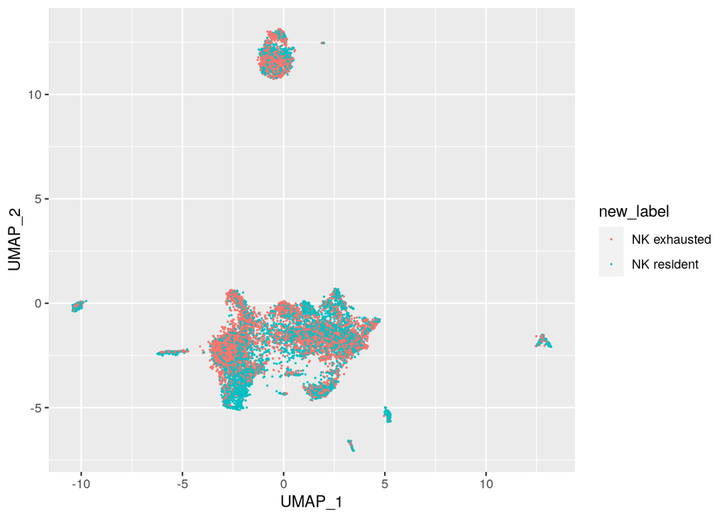

```r
Z_umap <-umap(Z)$layout
colnames(Z_umap) <- c("UMAP_1", "UMAP_2")
Z_umap <- merge(Z_umap, annotation, by="row.names")
row.names(Z_umap) <- Z_umap$Row.names
Z_umap$Row.names <- NULL
ggplot(Z_umap, aes(UMAP_1, UMAP_2, color = new_label)) + geom_point(size=0.1)
```

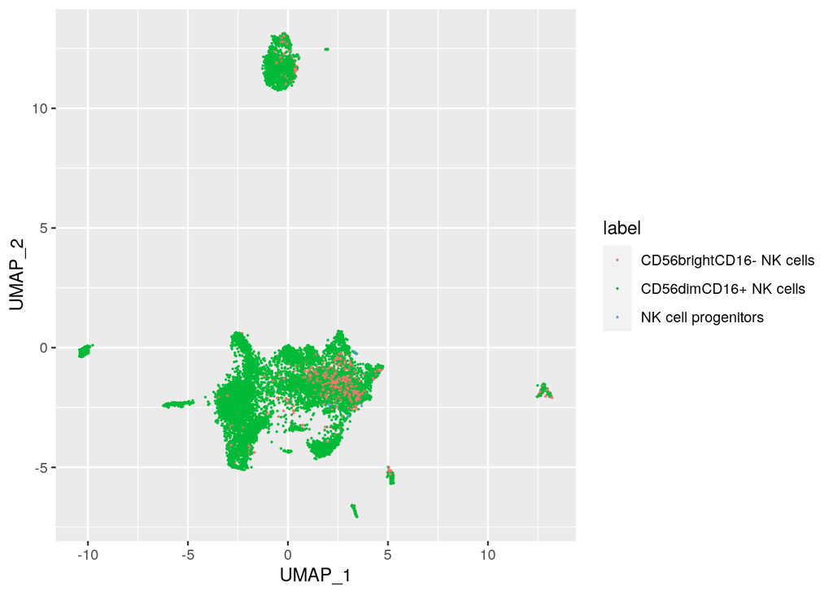

```r
ggplot(Z_umap, aes(UMAP_1, UMAP_2, color = label)) + geom_point(size=0.1)
```

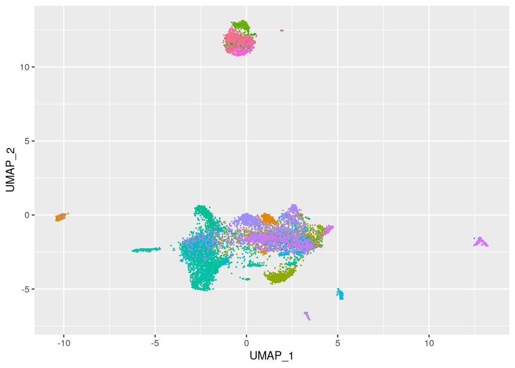

```r
ggplot(Z_umap, aes(UMAP_1, UMAP_2, color = batch)) + geom_point(size=0.1,show.legend = FALSE)
```

From the plots is possible to observe that, differently from Scenic, the TF activity is biased by the batch effect. Now let’s check if it is still possible to lcuster the TF activity by the state of our NK cells:

```r
cell_type_df <- data.frame(Exhausted = ifelse(annotation$new_label == "NK exhausted", 1, 0),
                           Resident = ifelse(annotation$new_label == "NK resident", 1, 0))

row.names(cell_type_df) <- row.names(annotation)
Z <- as.data.frame(Z)
Z_rf <- merge(Z, cell_type_df, by = "row.names")
row.names(Z_rf) <- Z_rf$Row.names
Z_rf$Row.names <- NULL

Z_exh <- Z_rf %>%
  select(-"Resident")

Z_exh$Exhausted <- factor(Z_exh$Exhausted )

fit_rf <- randomForest(Exhausted~., data = Z_exh)  ## build the RF model
Exh_tf_top100 <- importance(fit_rf)[order(importance(fit_rf)[, 1], decreasing = T), ][1:100]  ## Based on the feature importances identify the specific TFs for Exhausted cells

## Now for resident (Since the labels are one the opposite of the other, the most important TFs will be tha same so I decided to increase the number of TFs)
Z_res <- Z_rf %>%
  select(-"Exhausted")
Z_res$Resident <- factor(Z_res$Resident )

fit_rf <- randomForest(Resident~., data = Z_res)  ## build the RF model
Res_tf_top100 <- importance(fit_rf)[order(importance(fit_rf)[, 1], decreasing = T), ][1:10]  ## Based on the feature importances identify the specific TFs for Resident cells
```

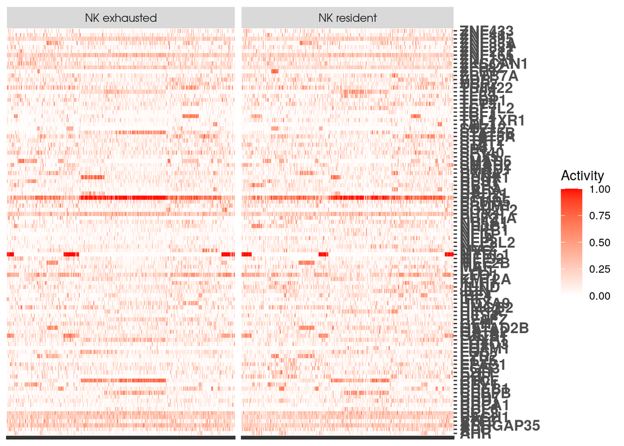

```r
## Build the inferred TF activities for selected TFs
selected_TFs = unique(sort(names(c(Exh_tf_top100, Res_tf_top100))))
#selected_TFs = names(Exh_tf_top10)
len_TFs = length(selected_TFs)

selected_TF_Z <- Z[, selected_TFs]
selected_TF_Z <- apply(selected_TF_Z, 2, function(x) (x-min(x))/(max(x)-min(x)))
label <- as.data.frame(annotation$new_label)
label$cells <- row.names(annotation)
colnames(label) <- c("label", "cells")


## Build the dataframe for heatmap
data_fr <- data.frame(cells = rep(rownames(selected_TF_Z), each = len_TFs), TF = rep(colnames(selected_TF_Z), 12560), stringsAsFactors = F)
data_fr$activity <- as.vector(as.matrix(t(selected_TF_Z)))
data_fr <- merge(data_fr, label, by="cells")
data_fr$TF <- factor(data_fr$TF, levels = colnames(selected_TF_Z))

## Generate heatmap figure
ggplot(data_fr, mapping = aes(x = cells, y = TF, fill = activity)) + geom_tile() +
  scale_fill_gradient(low = "white",
                      high = "red",
                      name = "Activity") +
  scale_y_discrete(position = "right", label = colnames(selected_TF_Z)) +
  facet_grid(facets = ~label,
             drop = TRUE,
             space = "free",
             scales = "free",
             aes(fill=cell_type)) +
  theme(axis.title.x=element_blank(),
        axis.text.x=element_blank(),
        axis.title.y=element_blank(),
        axis.text.y=element_text(size = 12, face="bold"),
        strip.text = element_text("none"))
```

# Does it make difference if I use the cell type?

```r
cell_type_df <- data.frame(cd56d = ifelse(annotation$label == "CD56dimCD16+ NK cells", 1, 0),
                           cd56b = ifelse(annotation$label == "CD56brightCD16- NK cells", 1, 0),
                           prog = ifelse(annotation$label == "NK cell progenitors", 1, 0))

row.names(cell_type_df) <- row.names(annotation)
Z <- as.data.frame(Z)
Z_rf <- merge(Z, cell_type_df, by = "row.names")
row.names(Z_rf) <- Z_rf$Row.names
Z_rf$Row.names <- NULL

Z_cd56d <- Z_rf %>%
  select(-c("cd56b","prog"))

Z_cd56d$cd56d <- factor(Z_cd56d$cd56d )

fit_rf <- randomForest(cd56d~., data = Z_cd56d)  ## build the RF model
cd56d_tf_top10 <- importance(fit_rf)[order(importance(fit_rf)[, 1], decreasing = T), ][1:10]  ## Based on the feature importances identify the specific TFs for Exhausted cells

## Now for resident (Since the labels are one the opposite of the other, the most important TFs will be tha same so I decided to increase the number of TFs)
Z_cd56b <- Z_rf %>%
  select(-c("cd56d","prog"))

Z_cd56b$cd56b <- factor(Z_cd56b$cd56b )

fit_rf <- randomForest(cd56b~., data = Z_cd56b)  ## build the RF model
cd56b_tf_top10 <- importance(fit_rf)[order(importance(fit_rf)[, 1], decreasing = T), ][1:10]  ## Based on the feature importances identify the specific TFs for Exhausted cells

## Now for resident (Since the labels are one the opposite of the other, the most important TFs will be tha same so I decided to increase the number of TFs)
Z_prog <- Z_rf %>%
  select(-c("cd56d","cd56b"))

Z_prog$prog <- factor(Z_prog$prog )

fit_rf <- randomForest(prog~., data = Z_prog)  ## build the RF model
prog_tf_top10 <- importance(fit_rf)[order(importance(fit_rf)[, 1], decreasing = T), ][1:10]  ## Based on the feature importances identify the specific TFs for Exhausted cells
```

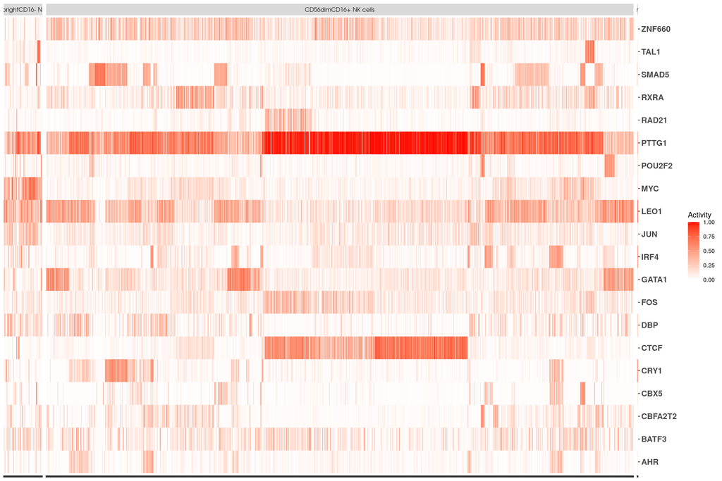

```r
## Build the inferred TF activities for selected TFs
#selected_TFs = unique(sort(names(c(Exh_tf_top100, Res_tf_top100))))
#selected_TFs = names(Exh_tf_top10)
selected_TFs <- unique(sort(names(c(cd56b_tf_top10, cd56d_tf_top10, prog_tf_top10))))
len_TFs = length(selected_TFs)

selected_TF_Z <- Z[, selected_TFs]
selected_TF_Z <- apply(selected_TF_Z, 2, function(x) (x-min(x))/(max(x)-min(x)))
label <- as.data.frame(annotation$label)
label$cells <- row.names(annotation)
colnames(label) <- c("label", "cells")


## Build the dataframe for heatmap
data_fr <- data.frame(cells = rep(rownames(selected_TF_Z), each = len_TFs), TF = rep(colnames(selected_TF_Z), 12560), stringsAsFactors = F)
data_fr$activity <- as.vector(as.matrix(t(selected_TF_Z)))
data_fr <- merge(data_fr, label, by="cells")
data_fr$TF <- factor(data_fr$TF, levels = colnames(selected_TF_Z))

## Generate heatmap figure
ggplot(data_fr, mapping = aes(x = cells, y = TF, fill = activity)) + geom_tile() +
  scale_fill_gradient(low = "white",
                      high = "red",
                      name = "Activity") +
  scale_y_discrete(position = "right", label = colnames(selected_TF_Z)) +
  facet_grid(facets = ~label,
             drop = TRUE,
             space = "free",
             scales = "free",
             aes(fill=cell_type)) +
  theme(axis.title.x=element_blank(),
        axis.text.x=element_blank(),
        axis.title.y=element_blank(),
        axis.text.y=element_text(size = 12, face="bold"),
        strip.text = element_text("none"))
```

No specific set of TFs have been found. Probably I will check with the enrichment, without running supercised ML algorithms and decide what to do.

## Normalized enrichment scores:

To evaluate the enrichment of the TFs in the cell states I am going to evaluate their enrichment and select the most enriched, then run the heatmap:

```r
## normalize data
normalize <- function(x, na.rm = TRUE) {
    return((x- min(x)) /(max(x)-min(x)))
}
## Sum normalized scores and select top enriched TFs
#Z_norm <-apply(Z, 2, function(x) (x-min(x))/(max(x)-min(x)))
Z_sum <- colSums(Z)/dim(Z)[1]
top_TFs <- head(sort(Z_sum,decreasing = TRUE), n=10)
#top_TFs <- sort(Z_sum,decreasing = TRUE)
```

Plot heatmap

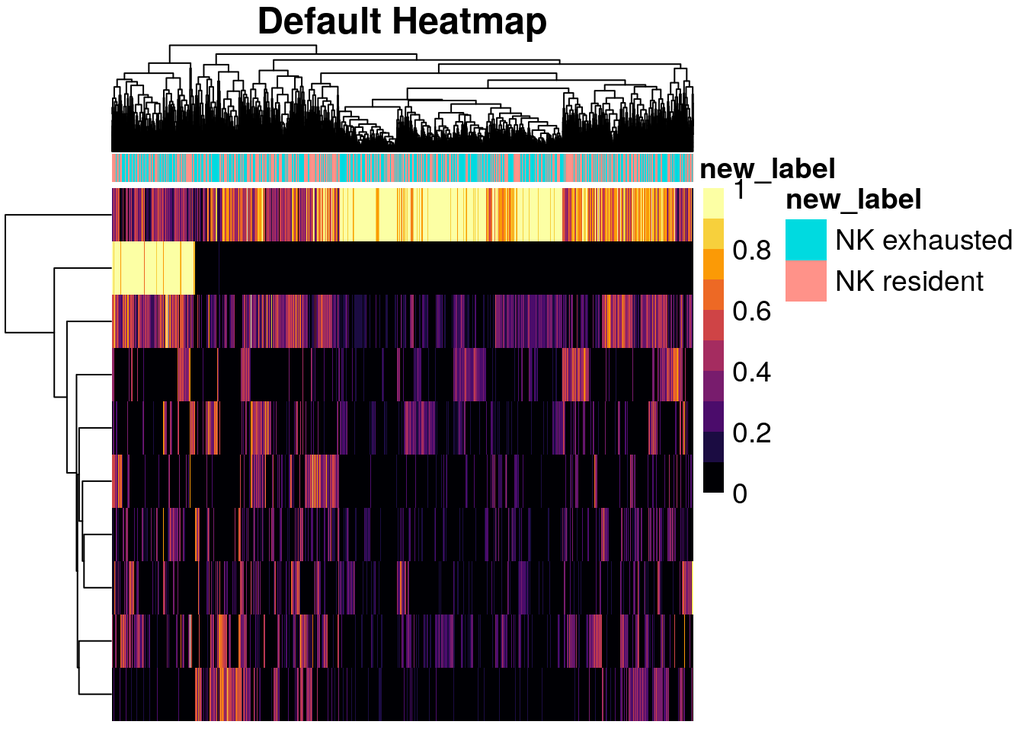

```r
library(pheatmap)
library(RColorBrewer)
library(viridis)
lables <- annotation%>%
  select("new_label")


Z_heat <- merge(Z, lables, by = "row.names")
row.names(Z_heat) <- Z_heat$Row.names
Z_heat$Row.names <- NULL

Z_heat_top_100 <- Z_heat %>%
  select(c(names(top_TFs))) %>%
  apply(2, function(x) (x-min(x))/(max(x)-min(x)))

Z_heat_top_100 <- merge(Z_heat_top_100, lables, by = "row.names")
row.names(Z_heat_top_100) <- Z_heat_top_100$Row.names
Z_heat_top_100$Row.names <- NULL


lab_colors <- list(group = brewer.pal(2, "Set1"))
names(lab_colors$group) <- unique(sort(lables$new_label))
lab_colors <- lab_colors[1:2]
lab_col <- Z_heat_top_100 %>%
  select(dim(Z_heat_top_100)[2])

tt <- data.table::transpose(Z_heat_top_100[,-dim(Z_heat_top_100)[2]])
rownames(tt) <- colnames(Z_heat_top_100[,-dim(Z_heat_top_100)[2]])
colnames(tt) <- rownames(Z_heat_top_100[,-dim(Z_heat_top_100)[2]])

pheatmap(
  mat               = tt,
  color             = inferno(10),
  border_color      = NA,
  show_colnames     = FALSE,
  show_rownames     = FALSE,
  annotation_col    = lab_col,
  annotation_colors = lab_colors,
  drop_levels       = TRUE,
  fontsize          = 14,
  main              = "Default Heatmap"
)
```

NOTE: the heatmap looks fine only if I normalize the data by column:

```r
summary(Z_heat_top_100)
```

```
##      PTTG1            MYBL1               LEO1            ZNF33A
##  Min.   :0.0000   Min.   :0.000000   Min.   :0.0000   Min.   :0.00000
##  1st Qu.:0.4807   1st Qu.:0.008501   1st Qu.:0.1053   1st Qu.:0.01653
##  Median :0.7198   Median :0.012694   Median :0.2575   Median :0.02484
##  Mean   :0.6824   Mean   :0.149492   Mean   :0.2715   Mean   :0.12073
##  3rd Qu.:0.9581   3rd Qu.:0.020404   3rd Qu.:0.4061   3rd Qu.:0.18251
##  Max.   :1.0000   Max.   :1.000000   Max.   :1.0000   Max.   :1.00000
##      FOXD2             ZNF555            COBLL1            ZNF331
##  Min.   :0.00000   Min.   :0.00000   Min.   :0.00000   Min.   :0.00000
##  1st Qu.:0.01515   1st Qu.:0.01910   1st Qu.:0.01353   1st Qu.:0.01448
##  Median :0.02990   Median :0.04846   Median :0.02939   Median :0.03122
##  Mean   :0.12503   Mean   :0.14684   Mean   :0.10393   Mean   :0.10153
##  3rd Qu.:0.22041   3rd Qu.:0.25611   3rd Qu.:0.16940   3rd Qu.:0.12658
##  Max.   :1.00000   Max.   :1.00000   Max.   :1.00000   Max.   :1.00000
##       DBP              SMAD5          new_label
##  Min.   :0.00000   Min.   :0.00000   Length:12560
##  1st Qu.:0.01357   1st Qu.:0.01044   Class :character
##  Median :0.02028   Median :0.01867   Mode  :character
##  Mean   :0.09754   Mean   :0.10702
##  3rd Qu.:0.04213   3rd Qu.:0.11302
##  Max.   :1.00000   Max.   :1.00000
```

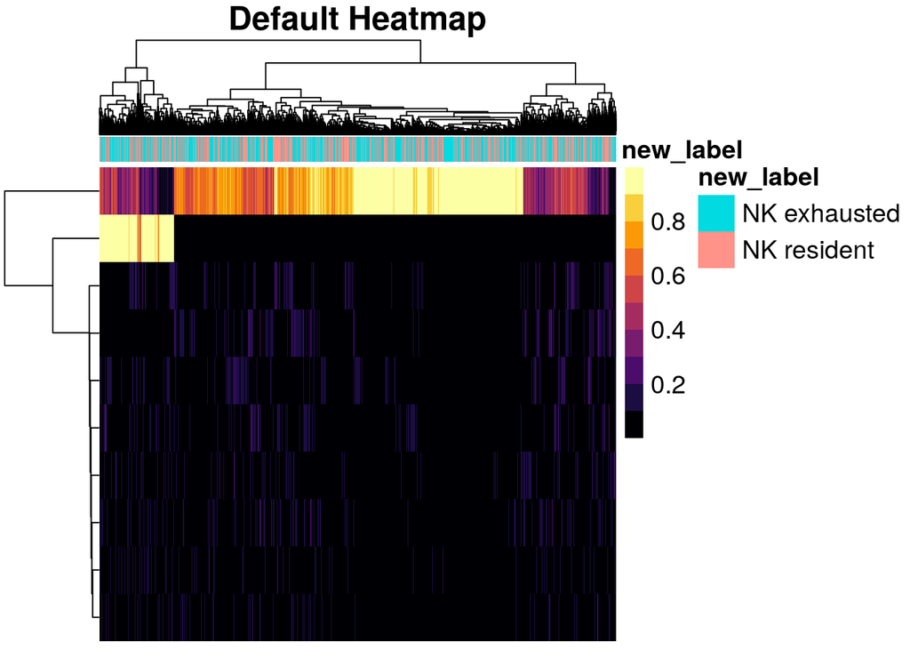

```r
lables <- annotation%>%
  select("new_label")


Z_heat <- merge(Z, lables, by = "row.names")
row.names(Z_heat) <- Z_heat$Row.names
Z_heat$Row.names <- NULL

Z_heat_top_100 <- Z_heat %>%
  select(c(names(top_TFs)))

Z_heat_top_100 <- merge(Z_heat_top_100, lables, by = "row.names")
row.names(Z_heat_top_100) <- Z_heat_top_100$Row.names
Z_heat_top_100$Row.names <- NULL


lab_colors <- list(group = brewer.pal(2, "Set1"))
names(lab_colors$group) <- unique(sort(lables$new_label))
lab_colors <- lab_colors[1:2]
lab_col <- Z_heat_top_100 %>%
  select(dim(Z_heat_top_100)[2])

tt <- data.table::transpose(Z_heat_top_100[,-dim(Z_heat_top_100)[2]])
rownames(tt) <- colnames(Z_heat_top_100[,-dim(Z_heat_top_100)[2]])
colnames(tt) <- rownames(Z_heat_top_100[,-dim(Z_heat_top_100)[2]])

pheatmap(
  mat               = tt,
  color             = inferno(10),
  border_color      = NA,
  show_colnames     = FALSE,
  show_rownames     = FALSE,
  annotation_col    = lab_col,
  annotation_colors = lab_colors,
  drop_levels       = TRUE,
  fontsize          = 14,
  main              = "Default Heatmap"
)
```

The results looks not correct so I decide to test again BITFAM devidin the NK cells by cell state and control other parameters.